# WaterFlow_Sector229

Thomas Houweling

10/8/2022

## Intro

Per eseguire, cambia directory nella linea di codice nella cella in basso con la directory contenente il file ‘flow (1).csv’ e specifica se (i) multicore o no (Se si possiamo specificare modelli piu’ complessi), (ii) salvare le immagini (5 o 6 per ciascun settore), (iii) salvare i dati (dati puliti, modello e forecast).

## Librerie

Useremo soprattutto zoo, tsibble e fable. Purtroppo questi pacchetti hanno molte funzioni con nomi simili (viva la fantasia!), creando quindi problemi di masking. Pertanto, carichiamo solo due librerie e per il resto chiamiamo esplicitamente il pacchetto quando esequiamo una funzione ambigua. Prima, installiamo le librerie mancanti.

## Carica dataset

In questo file esploriamo il primo settore nel dataset (settore 229) a titolo esemplificativo.

## Regolarizzazione TS

I dati sono irregolari. Per creare time series (TS) regolari uso il pacchetto zoo.

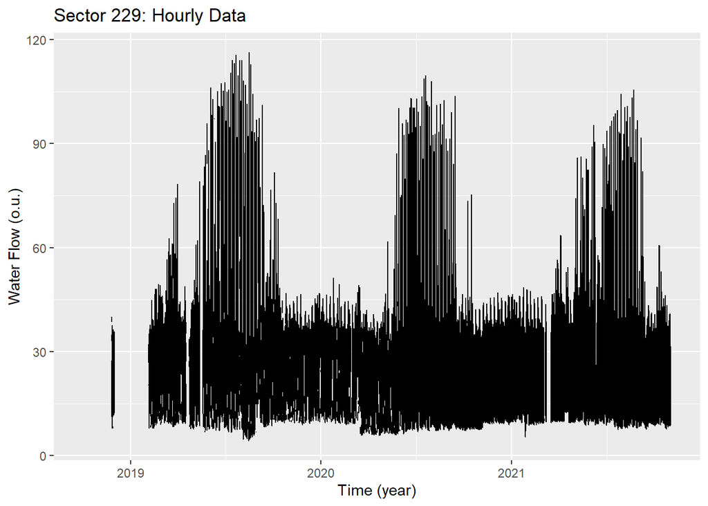

## Pulizia dataset

Dall’immagine possiamo notare come vi siano larghi chunk di dati mancanti prima di Febbraio/Marzo 2019 e piccoli chunck di dati mancanti successivamente. Iniziamo rimuovendo i dati iniziali.

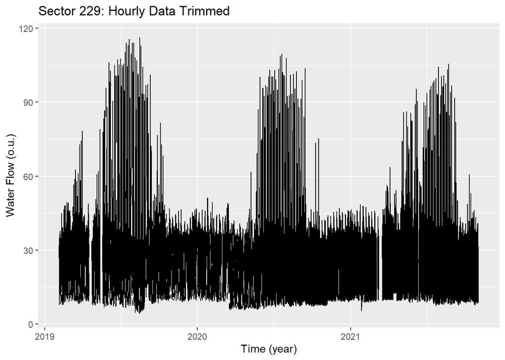

Molto meglio. Successivamente, interpoliamo i dati mancanti. Piuttosto che usare funzioni pre-compute (e.g., zoo::na.locf), scriviamo qualche linea di codice. Questo perche’ i dati sono estremamente variabili (noisy) e pertanto e’ meglio interpolare usando grandi chuncks di dati prima e dopo quelli mancanti. Specificamente, usiamo la media di tutti i valori nei 5 giorni antecedenti e successivi ai dati mancanti.

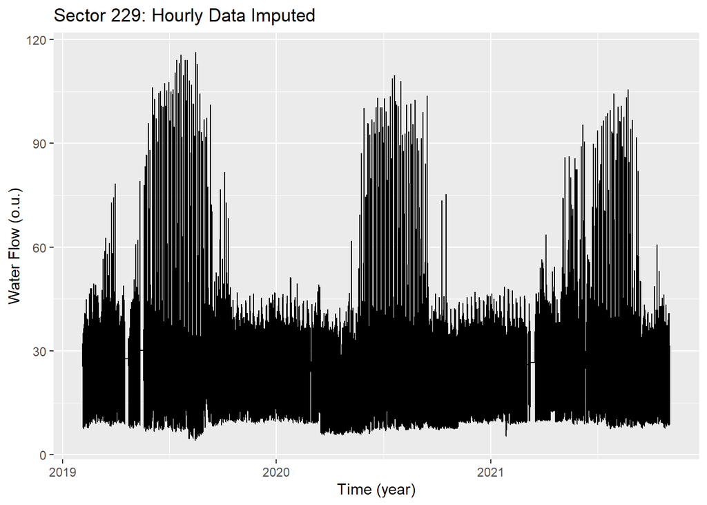

## Data Inspection

Dopo un minimo di pulizia iniziale, siamo pronti a ispezionare la nostra TS per stagionalita’ e trends. La ciclicita’ annuale e’ apparente. Ci possono pero’ essere anche stagionalita’ settimanali, diurne, ecc… In piu’ puo’ esserci un long-term trend (lineare o non lineare). Visualizziamo delle moving averages per vedere se ci sono long-term trends.

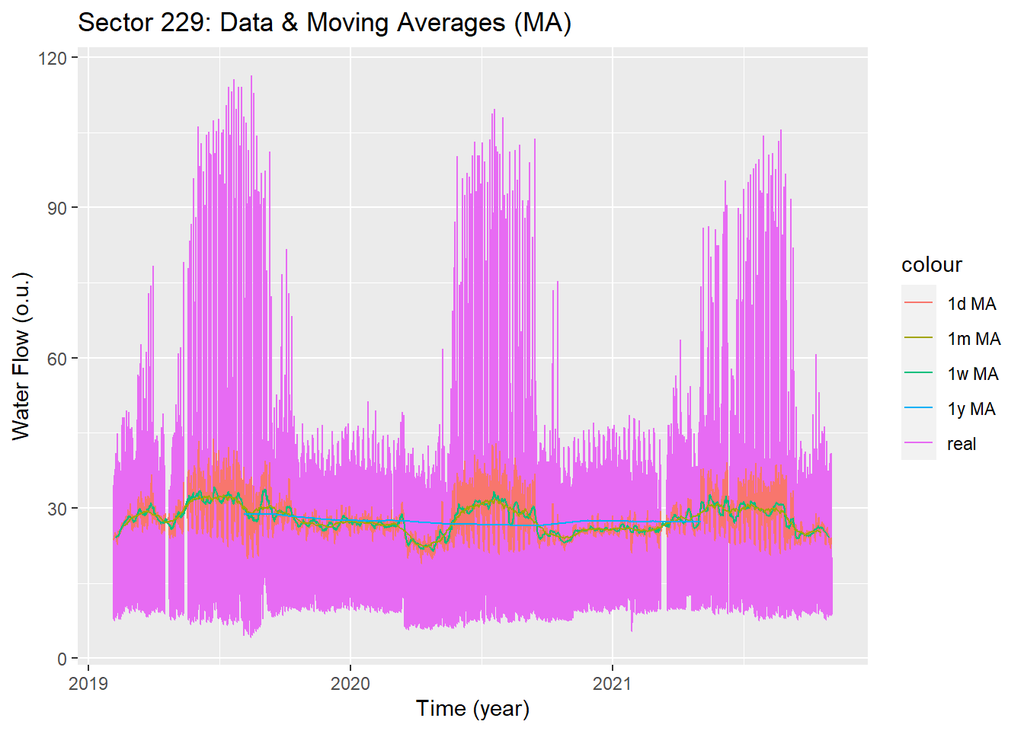

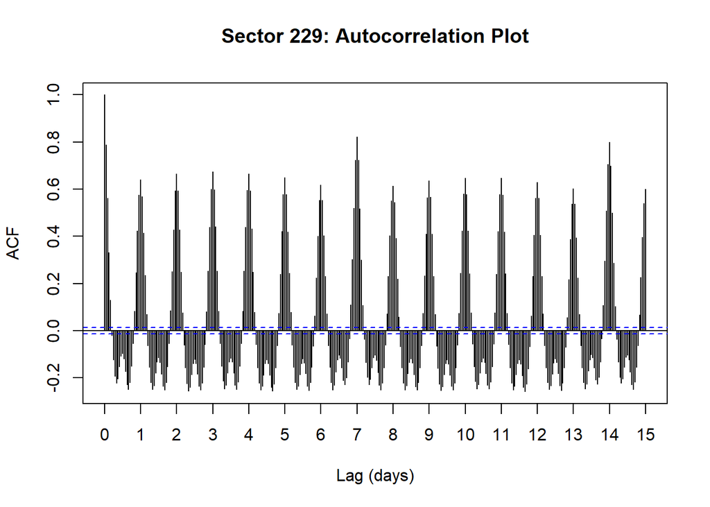

Un chiarissimo pattern giornaliero e’ apprezzabile, insieme a un meno significativo pattern settimanale. Il modello che fitteremo ai dati deve quindi contenere almeno la stagionalita’ annuale e giornaliera; meglio, se contiene anche quella settimanale. Procediamo ora a selezionare e fittare il modello, usando le librerie ‘tsibble’ e ‘fable’.

## Model fit

```
## Using `dayTime` as index variable.
```

```
## # A tibble: 1 x 1
##   .gaps
##   <lgl>
## 1 FALSE
```

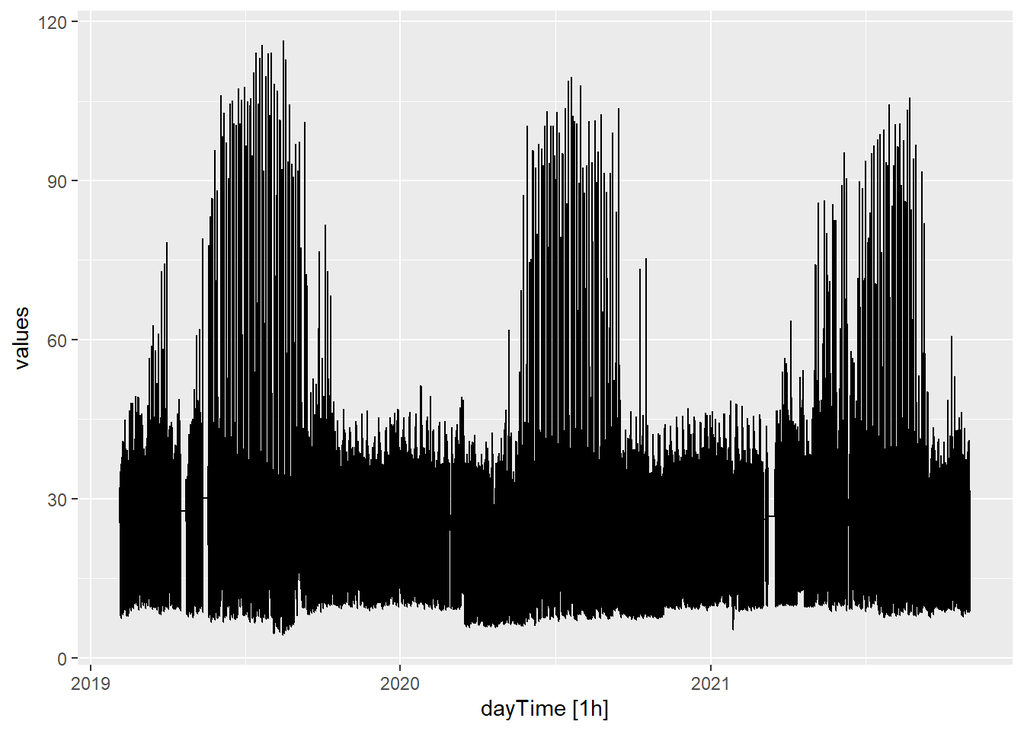

```
## Series: values
## Model: ARIMA(1,0,2)(2,1,0)[24]
##
## Coefficients:
##          ar1      ma1     ma2     sar1     sar2
##       0.6106  -0.0711  0.0499  -0.7017  -0.3569
## s.e.  0.0135   0.0148  0.0102   0.0060   0.0060
##
## sigma^2 estimated as 48.55:  log likelihood=-80701.5
## AIC=161415   AICc=161415   BIC=161463.5
```

## Forecast

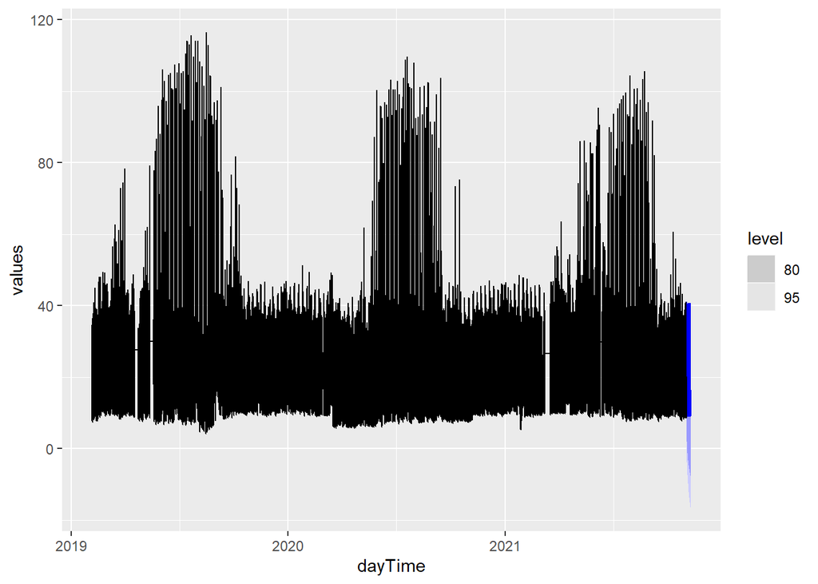

Come si evince dagli intervalli di confidenza, le predizioni non sono estremamente accurate, coprendo un largo range di valori.